# Администрирование локальных сетей

Лабораторная работа №15

Илья Колонтырский

Российский университет дружбы народов, Москва, Россия

17.05.2026

# Цели и задачи работы

## Цель лабораторной работы

Настроить динамическую маршрутизацию между территориями организации с использованием протокола **OSPF**.

## Задачи

- Настроить **OSPF** на маршрутизаторах:
  - **msk-donskaya-gw-1**
  - **msk-q42-gw-1**
  - **msk-hostel-gw-1**
  - **sch-sochi-gw-1**
- Организовать прямую связь между кварталом 42 и филиалом в Сочи.
- Проверить OSPF-соседства и таблицы маршрутизации.
- Отследить движение ICMP-пакета в режиме симуляции.
- Проверить изменение маршрута при отключении и восстановлении **VLAN 6**.

# Топология сети

## Общая схема сети

- Центральная площадка: **msk-donskaya**
- Сеть квартала 42: **msk-q42**
- Сеть общежития: **msk-hostel**
- Филиал в Сочи: **sch-sochi**
- Провайдерский участок связывает площадки между собой

## Общая схема сети

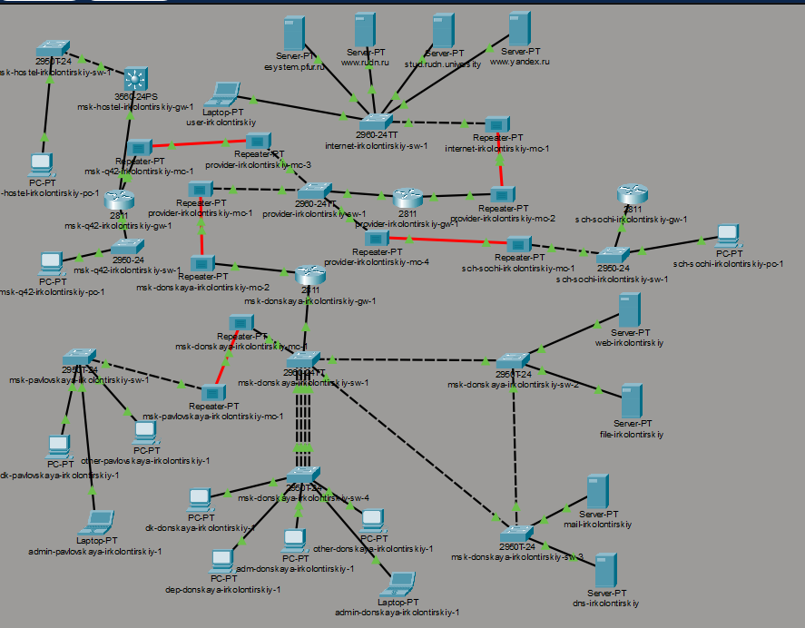

Общая топология сети в Cisco Packet Tracer

# Настройка OSPF

## Настройка OSPF на msk-donskaya-gw-1

- Запущен процесс **OSPF 1**
- Назначен идентификатор маршрутизатора: **10.128.254.1**
- В область **area 0** добавлена сеть **10.0.0.0/8**
- Конфигурация сохранена командой **wr mem**

## Настройка OSPF на msk-donskaya-gw-1

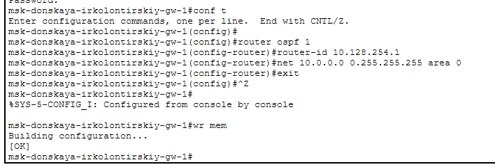

Настройка OSPF на маршрутизаторе msk-donskaya-gw-1

## Настройка OSPF на msk-q42-gw-1

- Запущен процесс **OSPF 1**
- Назначен **router-id 10.128.254.2**
- Добавлена сеть **10.0.0.0/8** в **area 0**
- Сформировано OSPF-соседство с **msk-donskaya-gw-1**
- Настроен подинтерфейс **FastEthernet0/1.7** для прямой связи с Сочи

## Настройка OSPF на msk-q42-gw-1

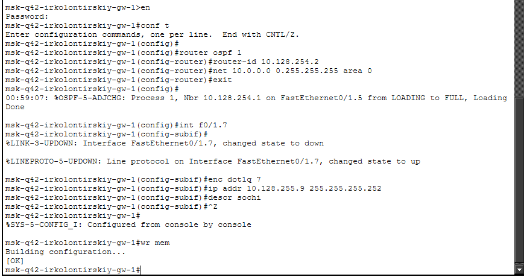

Настройка OSPF и подинтерфейса VLAN 7 на msk-q42-gw-1

## Настройка OSPF на msk-hostel-gw-1

- Запущен процесс **OSPF 1**
- Назначен **router-id 10.128.254.3**
- Добавлена сеть **10.0.0.0/8** в **area 0**
- Соседство установлено через интерфейс **Vlan202**
- Состояние соседства перешло в **FULL**

## Настройка OSPF на msk-hostel-gw-1

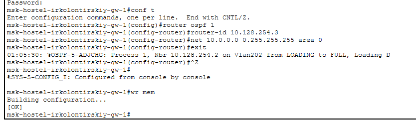

Настройка OSPF на маршрутизаторе msk-hostel-gw-1

## Настройка OSPF на sch-sochi-gw-1

- Запущен процесс **OSPF 1**
- Назначен **router-id 10.128.254.4**
- Добавлена сеть **10.0.0.0/8** в **area 0**
- Настроен подинтерфейс **FastEthernet0/0.7**
- Для прямой связи с кварталом 42 использована подсеть **10.128.255.8/30**

## Настройка OSPF на sch-sochi-gw-1

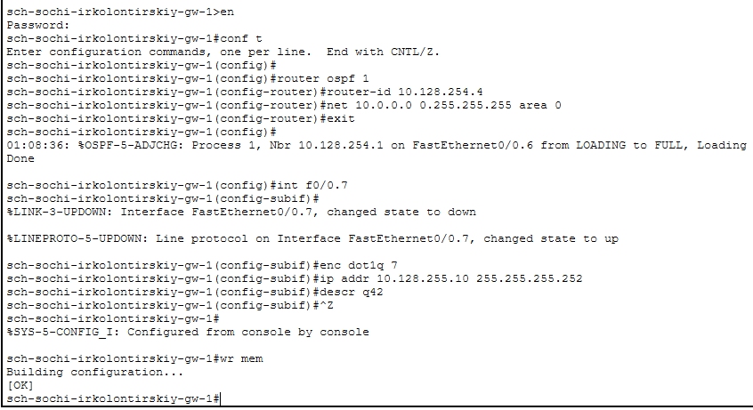

Настройка OSPF и подинтерфейса VLAN 7 на sch-sochi-gw-1

# Настройка прямого канала q42 — sochi

## Настройка VLAN 7

Для прямой связи между кварталом 42 и филиалом в Сочи был создан **VLAN 7** с именем **q42-sochi**.

VLAN был настроен на коммутаторах: - **provider-irkolontirskiy-sw-1** - **sch-sochi-irkolontirskiy-sw-1**

## VLAN 7 на коммутаторе провайдера

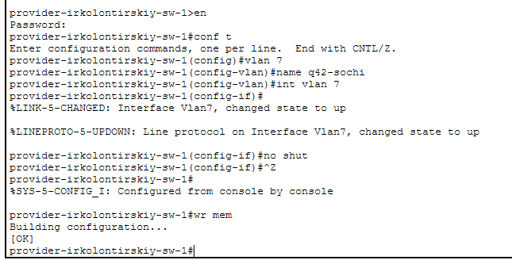

Создание VLAN 7 на коммутаторе provider-sw-1

## VLAN 7 на коммутаторе филиала

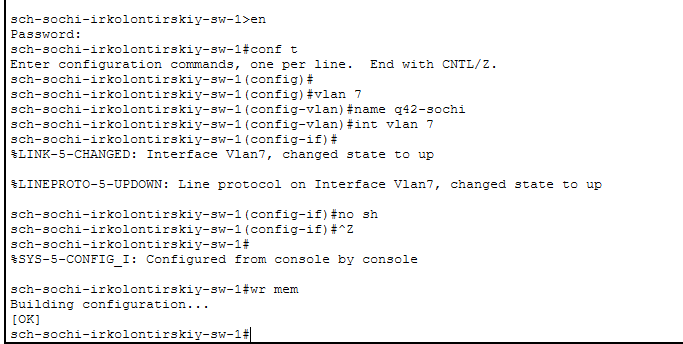

Создание VLAN 7 на коммутаторе sch-sochi-sw-1

# Проверка OSPF

## Проверка процесса OSPF

На маршрутизаторе **msk-donskaya-gw-1** была выполнена проверка процесса OSPF.

Проверка показала: - активен процесс **OSPF 1** - используется **router-id 10.128.254.1** - маршрутизатор работает в области **BACKBONE area 0** - в области участвует **8 интерфейсов**

## Проверка процесса OSPF

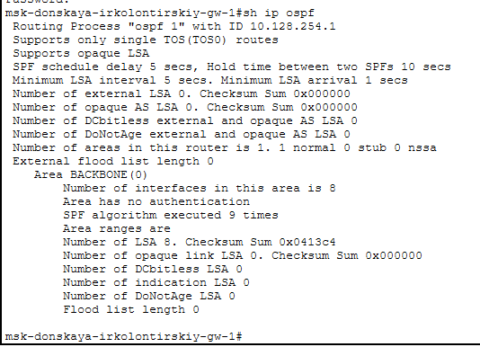

Проверка процесса OSPF на msk-donskaya-gw-1

## Проверка соседей на msk-donskaya-gw-1

На маршрутизаторе **msk-donskaya-gw-1** были обнаружены соседи:

| Neighbor ID | Адрес | Интерфейс | Состояние |
| --- | --- | --- | --- |
| 10.128.254.2 | 10.128.255.2 | FastEthernet0/1.5 | FULL/BDR |
| 10.128.254.4 | 10.128.255.6 | FastEthernet0/1.6 | FULL/BDR |

## Таблица маршрутизации msk-donskaya-gw-1

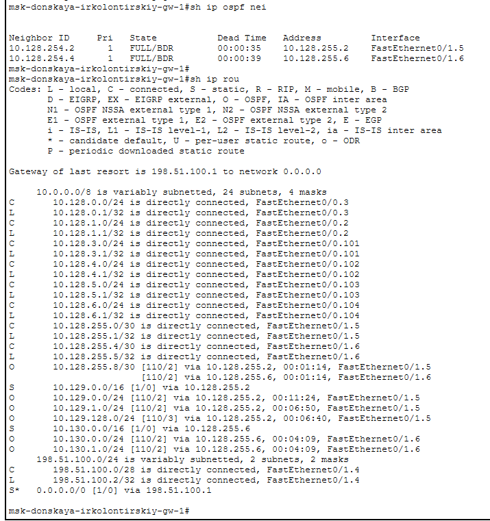

Проверка соседей OSPF и таблицы маршрутизации на msk-donskaya-gw-1

## Проверка соседей на msk-q42-gw-1

На маршрутизаторе **msk-q42-gw-1** были обнаружены три OSPF-соседа:

| Neighbor ID | Адрес | Интерфейс |
| --- | --- | --- |
| 10.128.254.4 | 10.128.255.10 | FastEthernet0/1.7 |
| 10.128.254.1 | 10.128.255.1 | FastEthernet0/1.5 |
| 10.128.254.3 | 10.129.1.2 | FastEthernet1/0.202 |

## Таблица маршрутизации msk-q42-gw-1

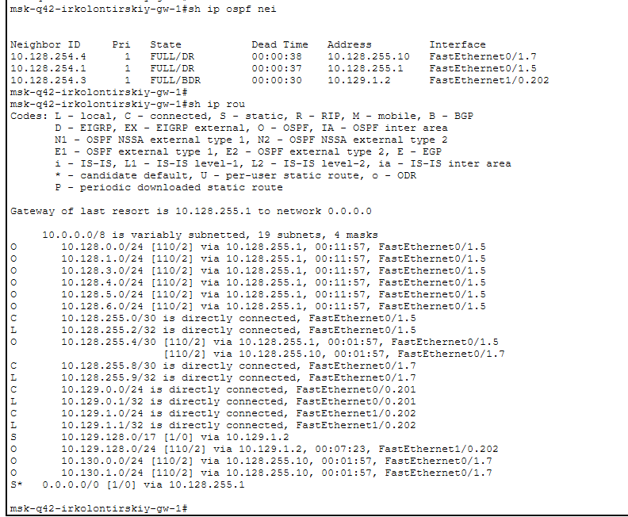

Проверка соседей OSPF и таблицы маршрутизации на msk-q42-gw-1

## Проверка msk-hostel-gw-1

- Маршрутизатор **msk-hostel-gw-1** установил соседство с **msk-q42-gw-1**
- Сосед доступен через адрес **10.129.1.1**
- Интерфейс подключения: **Vlan202**
- Состояние соседства: **FULL/DR**
- Удалённые сети доступны через OSPF

## Таблица маршрутизации msk-hostel-gw-1

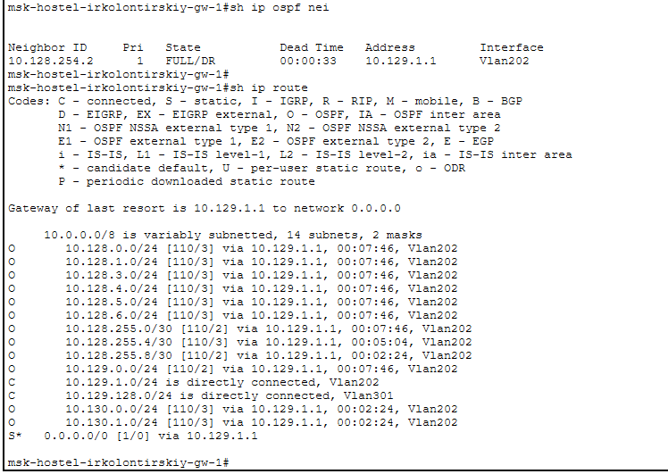

Проверка соседей OSPF и таблицы маршрутизации на msk-hostel-gw-1

## Проверка sch-sochi-gw-1

На маршрутизаторе **sch-sochi-gw-1** отображаются два OSPF-соседа:

| Neighbor ID | Адрес | Интерфейс |
| --- | --- | --- |
| 10.128.254.2 | 10.128.255.9 | FastEthernet0/0.7 |
| 10.128.254.1 | 10.128.255.5 | FastEthernet0/0.6 |

## Таблица маршрутизации sch-sochi-gw-1

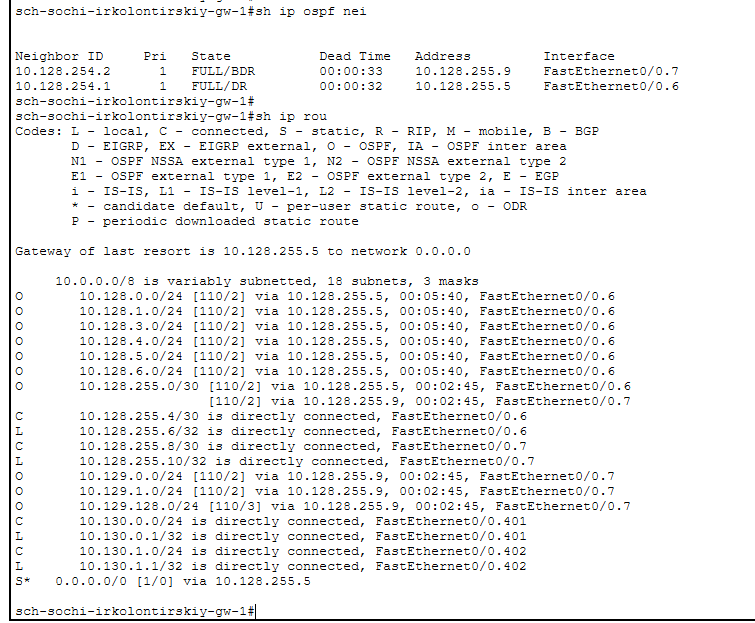

Проверка соседей OSPF и таблицы маршрутизации на sch-sochi-gw-1

# Проверка ICMP

## ICMP при рабочем VLAN 6

В режиме **Simulation** была выполнена проверка передачи ICMP-пакета от ноутбука администратора на Донской до компьютера пользователя в Сочи.

- Источник: **Laptop-PT admin**
- Получатель: **pc-sochi-1**
- IP-адрес получателя: **10.130.0.200**
- Используется основной маршрут через **VLAN 6**

## ICMP при рабочем VLAN 6

[figure not shown]

Прохождение ICMP-пакета в режиме симуляции при рабочем VLAN 6

## Трассировка при рабочем VLAN 6

Маршрут до **10.130.0.200**:

| № | Узел |
| --- | --- |
| 1 | 10.128.6.1 |
| 2 | 10.128.255.6 |
| 3 | 10.130.0.200 |

Маршрут проходит по основному каналу между центральной площадкой и филиалом в Сочи.

## Трассировка при рабочем VLAN 6

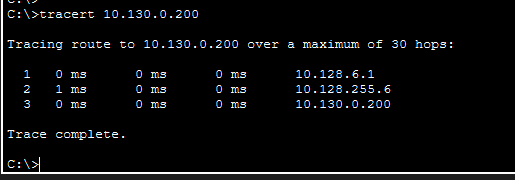

Трассировка маршрута до pc-sochi-1 при рабочем VLAN 6

# Проверка резервного маршрута

## Отключение VLAN 6

На коммутаторе **provider-irkolontirskiy-sw-1** был временно отключен **VLAN 6**.

После отключения интерфейса появились сообщения: - **Interface Vlan6, changed state to down** - **Line protocol on Interface Vlan6, changed state to down**

## Отключение VLAN 6

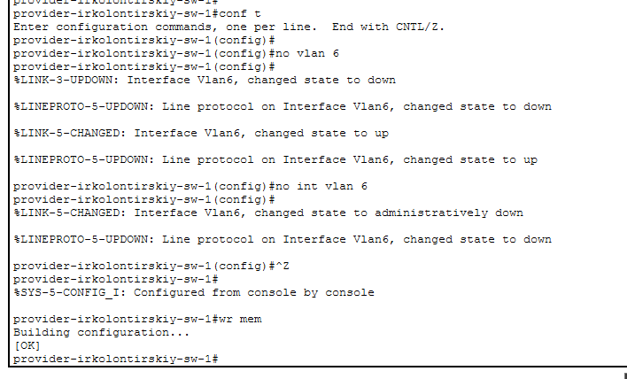

Отключение VLAN 6 на коммутаторе провайдера

## ICMP после отключения VLAN 6

После отключения **VLAN 6** маршрут ICMP-пакета изменился.

Трафик начал проходить через: - сеть квартала 42, - маршрутизатор **msk-q42-gw-1**, - прямой канал **VLAN 7**, - маршрутизатор **sch-sochi-gw-1**.

## ICMP после отключения VLAN 6

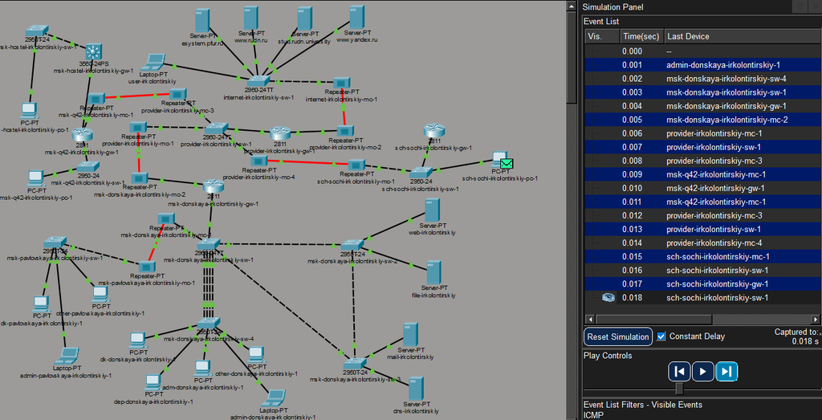

Прохождение ICMP-пакета после отключения VLAN 6

## Трассировка после отключения VLAN 6

Маршрут до **10.130.0.200**:

| № | Узел |
| --- | --- |
| 1 | 10.128.6.1 |
| 2 | 10.128.255.2 |
| 3 | 10.128.255.10 |
| 4 | 10.130.0.200 |

Количество переходов увеличилось с трёх до четырёх.

## Трассировка после отключения VLAN 6

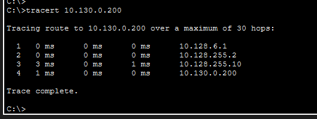

Трассировка маршрута после отключения VLAN 6

# Восстановление основного маршрута

## Восстановление VLAN 6

После проверки резервного маршрута на коммутаторе провайдера был восстановлен **VLAN 6**.

- Создан VLAN **6**
- Назначено имя **sochi**
- Интерфейс **Vlan6** включен командой **no shutdown**
- Конфигурация сохранена командой **wr mem**

## Восстановление VLAN 6

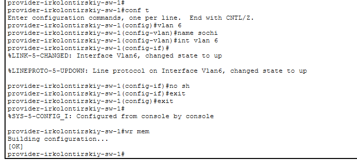

Восстановление VLAN 6 на коммутаторе провайдера

## ICMP после восстановления VLAN 6

После восстановления **VLAN 6** ICMP-пакет снова начал проходить по основному маршруту между центральной площадкой и филиалом в Сочи.

Обходной путь через квартал 42 перестал использоваться.

## ICMP после восстановления VLAN 6

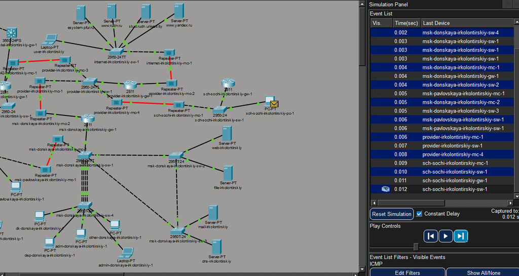

Прохождение ICMP-пакета после восстановления VLAN 6

## Трассировка после восстановления VLAN 6

Маршрут до **10.130.0.200** снова состоит из трёх переходов:

| № | Узел |
| --- | --- |
| 1 | 10.128.6.1 |
| 2 | 10.128.255.6 |
| 3 | 10.130.0.200 |

## Трассировка после восстановления VLAN 6

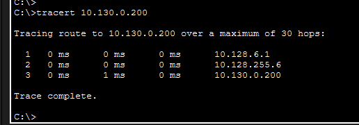

Трассировка маршрута после восстановления VLAN 6

# Выводы

## Вывод

В ходе работы была настроена динамическая маршрутизация по протоколу **OSPF** между несколькими территориями организации.

Были выполнены: - настройка OSPF на маршрутизаторах; - создание прямого канала между кварталом 42 и Сочи через **VLAN 7**; - проверка OSPF-соседств; - анализ таблиц маршрутизации; - проверка прохождения ICMP-пакетов; - проверка переключения маршрута при отключении **VLAN 6**.